# K-Modes

2024-07-11

K-modes is a clustering algorithm designed specifically to handle categorical data. K-modes replaces the cluster mean used in K-means with the mode—the most frequent value for each categorical variable. It calculates the distance between data points using a matching dissimilarity measure that counts the number of mismatches between categorical variables. K-modes can be more effective than K-means when working with categorical data.

In summary, K-means is a clustering algorithm that works well with numerical data, whereas K-modes is a clustering algorithm designed specifically to handle categorical data.

# Load database

You need to have run at least the initial part of the LCA—not the entire LCA, but enough to establish the baseline used for all the analyses. I’m taking the comorbidities from that.

```r
myMMcondition[,2:ncol(myMMcondition)] = apply(myMMcondition[,2:ncol(myMMcondition)], 2, function(x) as.numeric(as.character(x)));
```

```r
nrow(myMMcondition)
```

```
## [1] 51835
```

# Regular kmodes

```r
J = 7 # Highest number of clusters to try

myresult <- SSW <- vector("list",J)

library(klaR)

#pb <- txtProgressBar(min = 0,      # Valor mínimo de la barra de progreso
#                     max = J, # Valor máximo de la barra de progreso
#                     style = 3,    # Estilo de la barra (también style = 1 y style = 2)
#                     width = 50,   # Ancho de la barra. Por defecto: getOption("width")
#                     char = "=")   # Carácter usado para crear la barra
```

```r
set.seed(43)
myresult[[1]] <- kmodes(myMMcondition[,-1], 1, iter.max = 5000, weighted=FALSE)

myresult[[2]] <- kmodes(myMMcondition[,-1], 2, iter.max = 5000, weighted=FALSE)
```

```r
set.seed(43)
myresult[[3]] <- kmodes(myMMcondition[,-1], 3, iter.max = 5000, weighted=FALSE)
```

```r
set.seed(43)

myresult[[4]] <- kmodes(myMMcondition[,-1], 4, iter.max = 5000, weighted=FALSE)

myresult[[5]] <- kmodes(myMMcondition[,-1], 5, iter.max = 5000, weighted=FALSE)
```

```r
set.seed(43)

myresult[[6]] <- kmodes(myMMcondition[,-1], 6, iter.max = 5000, weighted=FALSE)

myresult[[7]] <- kmodes(myMMcondition[,-1], 7, iter.max = 5000, weighted=FALSE)
```

# The rest: show results

Cargo resultados

By default, simple matching distance is used to determine the dissimilarity between two objects. It is calculated by counting the number of dissimilarities across all variables. Alternatively, this distance can be weighted based on category frequencies in the data (see Huang, 1997, for details).

Methods: https://uc-r.github.io/kmeans_clustering#silo

# Elbow method

The goal is to define clusters such that the total within-cluster variation (total within-cluster sum of squares) is minimized. The location of the “elbow” or bend in the TWSS plot is typically considered an indicator of the appropriate number of clusters.

withindiff: simple matching distances within the group for each cluster. This represents SW—the standard deviation of a specific group.

The sum of SW values—that is, SSW (sum of squares within clusters; note that this differs from TWSS, where SSB = TSS - SSW)—can be calculated by summing these figures across all groups. As the number of clusters increases, SSW is expected to decrease. This SSW value itself can serve as a metric for cluster validation.

https://iopscience.iop.org/article/10.1088/1757-899X/1087/1/012085/pdf

```r
num_clusters <- 1:length(myresult)
SSW <- c()
for (k in num_clusters) {
  SSW <- c(SSW, sum(myresult[[k]][["withindiff"]])) # cogido de internet
                                                    # literal, o sea bien
}
```

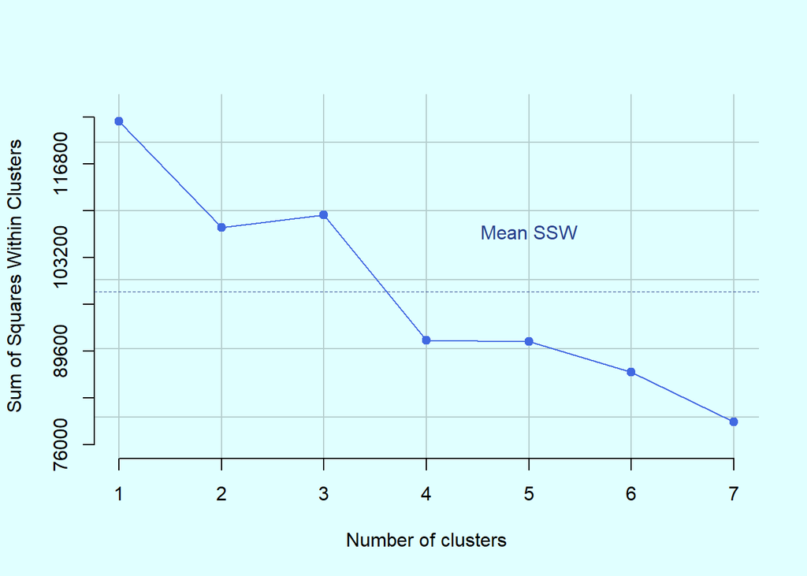

```r
par(bg = '#E0FFFF') # background

plot(num_clusters, SSW, pch=19, col='#4169E1', main=NULL, xlab = 'Number of clusters', ylab = 'Sum of Squares Within Clusters', axes = FALSE, ylim = c(76000, 125000), panel.first=grid(lty = 1,      # Grid line type
     col = "#B4CDCD", # Grid line color
     lwd = 1))
lines(num_clusters, SSW, lwd =1, col='#4169E1')

axis(1, at = seq(1, 7, by = 1)) # eje y

axis(2, at = seq(76000, 125000, by = 6800)) # eje y

abline(h=mean(SSW), col="#27408B", lwd = 0.5, lty = 2:3) # pongo la media en azul

text(5, 107000, 'Mean SSW', col = "#27408B", cex = 1)
```

```r
#  theme(panel.background = element_rect(fill = "#F0FFFF", colour = "#E0FFFF",
#             size = 0.5, linetype = "solid"),
#  panel.grid = element_line(size = 0.25, linetype = 'solid',
#                                colour = "#B4CDCD"),
#  axis.text = element_text(colour = "black"),
#  axis.title = element_text(colour = "black"))
```

The SSW should decrease—though here it sometimes increases—and we should focus on the “elbows.” There are elbows notably at points 2 (not clinically significant), 3, 5, and 6. The slopes are similar between points 1 and 2, 3 and 4, and 6 and 7 (meaning the latter are of less interest).

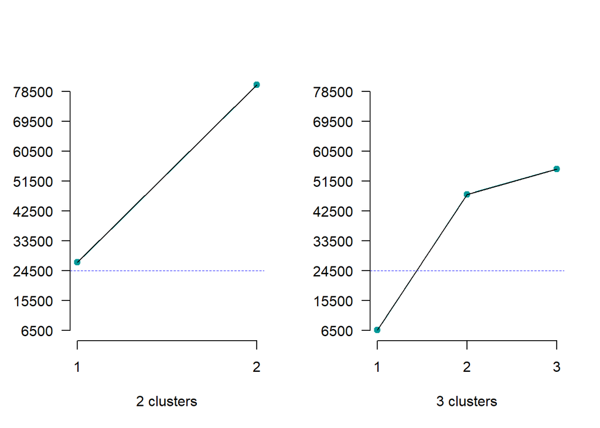

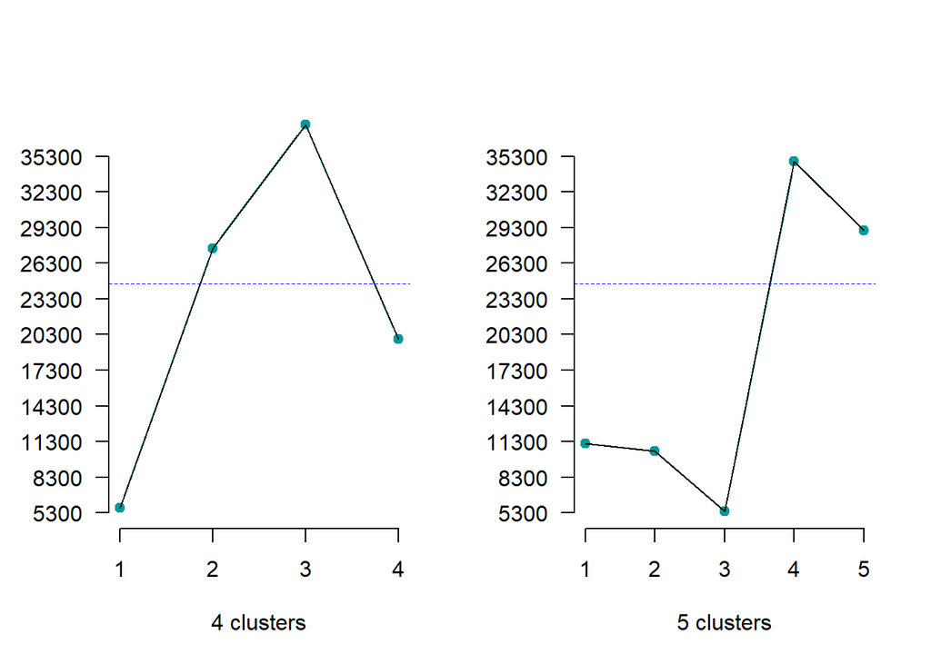

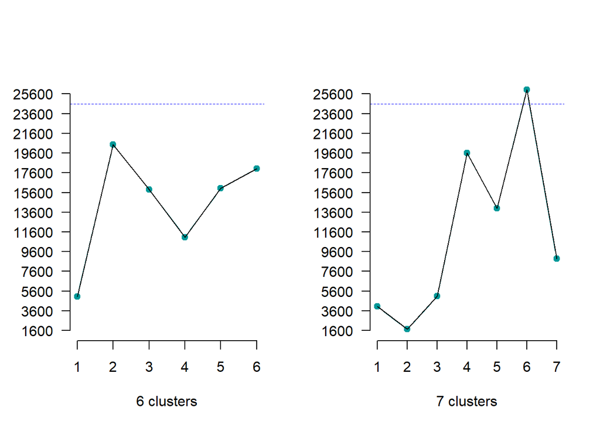

```r
mediaWithinDiff=mean(c(myresult[[1]][["withindiff"]], myresult[[2]][["withindiff"]], myresult[[3]][["withindiff"]], myresult[[4]][["withindiff"]], myresult[[5]][["withindiff"]], myresult[[6]][["withindiff"]], myresult[[7]][["withindiff"]]))


par(mfrow = c(1,2))

for(i in 2:J){

  # antes estaban el plot() # ylab yaxt xlab=  etc, o sea todo,
              # fuera de los if. Es para que se vea mejor

    if (i<=3) {

      plot(as.numeric(myresult[[i]][["withindiff"]]), pch=19, col='#009999', type="b", frame = FALSE, ylim = c(6500,82000) ,
     # ylab="Total within-clusters sum of squares",
     yaxt="n", ylab = NA, xaxt='n',
     xlab=paste(c(i, 'clusters'),collapse=" "))

      lines(as.numeric(myresult[[i]][["withindiff"]]), lwd =1) # linea negra

      abline(h=mediaWithinDiff, col="blue", lwd = 0.5, lty = 2:3) # pongo el SSW de ese grupo

      axis(2, at = seq(6500, 82000, by = 9000), las=2)

      axis(1, at = round(1:i), las=1)
    }

    else if(i==4 | i==5) {

      plot(as.numeric(myresult[[i]][["withindiff"]]), pch=19, col='#009999', type="b", frame = FALSE, ylim = c(5300, 38000) ,
     yaxt="n", ylab = NA, xaxt='n',
     xlab=paste(c(i, 'clusters'),collapse=" "))

      lines(as.numeric(myresult[[i]][["withindiff"]]), lwd =1)

      abline(h=mediaWithinDiff, col="blue", lwd = 0.5, lty = 2:3)

      axis(2, at = seq(5300, 38000, by = 3000), las=2)

      axis(1, at = round(1:i), las=1)
    }



    else {

      plot(as.numeric(myresult[[i]][["withindiff"]]), pch=19, col='#009999', type="b", frame = FALSE, ylim = c(1600, 27000) ,
     # ylab="Total within-clusters sum of squares",
     yaxt="n", ylab = NA, xaxt='n',
     xlab=paste(c(i, 'clusters'),collapse=" "))

      lines(as.numeric(myresult[[i]][["withindiff"]]), lwd =1)

      abline(h=mediaWithinDiff, col="blue", lwd = 0.5, lty = 2:3)

      axis(2, at = seq(1600, 27000, by = 2000), las=2)

      axis(1, at = round(1:i), las=1)
    }


  # lines(1:i, as.numeric(strsplit(as.character(SSW[[i]]), ", ")[[1]]))
}
```

```r
par(mfrow = c(1,1))
```

SSW is the sum of squared differences between a value and its sample mean across all values. The model attempts to minimize this measure of model quality. This is known as the Within-Cluster Sum of Squares (WCSS), which is the sum of the distances between data points and their corresponding centroid for each cluster. The lower this quality measure, the closer we get to the optimal model (a process performed by the algorithm).

```r
cat('Mayor valor del cluster 1:', max(as.numeric(unlist(stringr::str_split(max(SSW[[1]]), pattern=', ')))))
```

```
## Mayor valor del cluster 1: 123002
```

```r
cat('Mayor valor del cluster 2:', max(as.numeric(unlist(stringr::str_split(max(SSW[[2]]), pattern=', ')))))
```

```
## Mayor valor del cluster 2: 107606
```

```r
cat('Mayor valor del cluster 3:', max(as.numeric(unlist(stringr::str_split(max(SSW[[3]]), pattern=', ')))))
```

```
## Mayor valor del cluster 3: 109419
```

```r
cat('Mayor valor del cluster 4:', max(as.numeric(unlist(stringr::str_split(max(SSW[[4]]), pattern=', ')))))
```

```
## Mayor valor del cluster 4: 91201
```

```r
cat('Mayor valor del cluster 5:', max(as.numeric(unlist(stringr::str_split(max(SSW[[5]]), pattern=', ')))))
```

```
## Mayor valor del cluster 5: 91003
```

```r
cat('Mayor valor del cluster 6:', max(as.numeric(unlist(stringr::str_split(max(SSW[[6]]), pattern=', ')))))
```

```
## Mayor valor del cluster 6: 86543
```

```r
cat('Mayor valor del cluster 7:', max(as.numeric(unlist(stringr::str_split(max(SSW[[7]]), pattern=', ')))))
```

```
## Mayor valor del cluster 7: 79323
```

```r
k=3
cluster.output <- cbind(myMMcondition,myresult[[k]]$cluster)
```

```r
colnames(cluster.output)[ncol(cluster.output)]='KModes'
saveRDS(cluster.output, 'KModesResult.RDS')

rm(cluster.output)
```

# Average silhouette method

https://uc-r.github.io/kmeans_clustering#silo

With Jaccard distances

```r
# install.packages("ade4")
memory.limit(size=1e+13)
```

```
## [1] Inf
```

```r
rownames(myMMcondition)=1:nrow(myMMcondition)


myMMconditionParaDist=apply(myMMcondition, 2, function(x) as.numeric(as.character(x)))
rownames(myMMconditionParaDist)=1:nrow(myMMconditionParaDist)

#distancias=dist(myMMconditionParaDist, method = "binary") # es lo mismo, hace Jaccard


#### negative length vectors not allowedmensaje de error ####
###### significa que su sesión R se ha quedado sin memoria ######
```

This cannot be done with categorical or factor data; it will cause an error later. Set the data to numeric.

Set any k you want

This next function calculates the average silhouette width, just like “fviz_nbclust”, but I trust the latter more than others

```r
# function to compute average silhouette for k clusters

avg_sil <- function(k) {
  km.res <- myresult[[k]][["cluster"]]
  ss <- cluster::silhouette(x=km.res, dist=distancias)
  # calcular el ancho de silueta promedio
  mean(ss[, 3])
}

# Compute and plot wss
k.values <- 2:7 # no sale con 1
```

```r
# extract avg silhouette
avg_sil_values <- purrr::map_dbl(k.values, avg_sil)
```

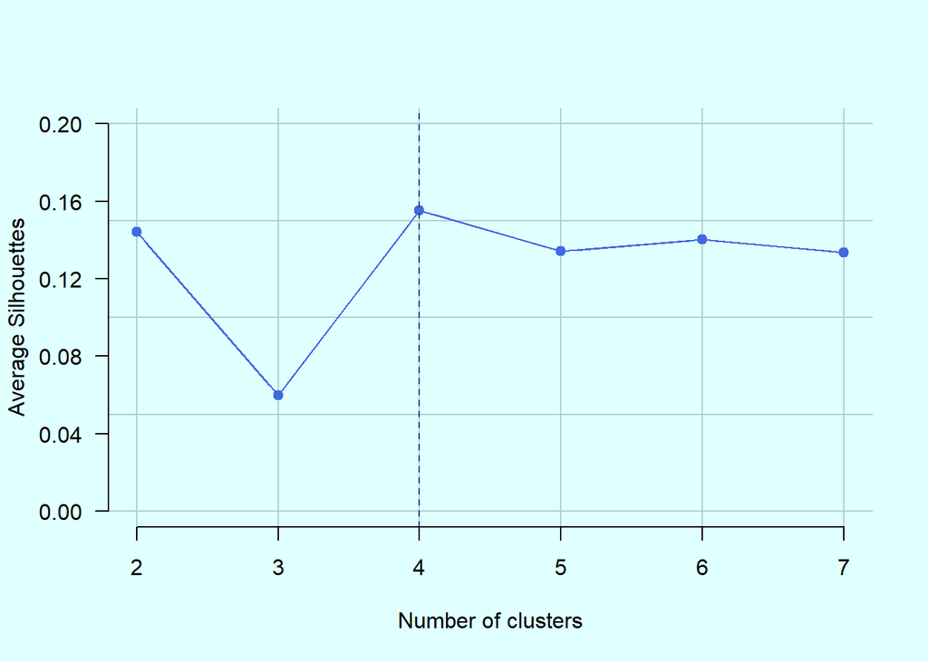

```r
par(bg = '#E0FFFF') # background


plot(k.values, avg_sil_values, axes = FALSE,   # va del 0.05 al 0.12 aprox
       type = "b", pch = 19, frame = FALSE,
       xlab = "Number of clusters",
       ylab = "Average Silhouettes",
     col='#4169E1', ylim = c(0.0, 0.20), panel.first=grid(lty = 1,      # Grid line type
                                                                                                                                                                                        col = "#B4CDCD", # Grid line color
                                                                                                                                                                                        lwd = 1))

lines(k.values, avg_sil_values, lwd =1, col='#4169E1')

abline(v = which.max(avg_sil_values)+1, col = c("#27408B"),
       lwd = 1,
       lty = 2:3)
    # +1 porque el 1 es en realidad 2 clusters

axis(1, k.values) # eje y

axis(2, at = seq(0, 0.2, by = 0.04), las=2)
```

The silhouette value is a measure of how similar an object is to its own cluster (cohesion) compared to other clusters (separation). The silhouette ranges from −1 to +1, where a high value indicates that the object is well-matched to its own cluster and poorly matched to neighboring clusters. In short, the average silhouette method measures the quality of a clustering—that is, it determines how well each object is positioned within its cluster. A high average silhouette width indicates good clustering. The average silhouette method calculates the average silhouette of the observations for different values of k. The optimal number of clusters, k, is the one that maximizes the average silhouette across a range of possible values for k.

I place more trust in this (IT IS THE SAME THING; both represent the mean average silhouette width):

```r
set.seed(43)

library(factoextra)
```

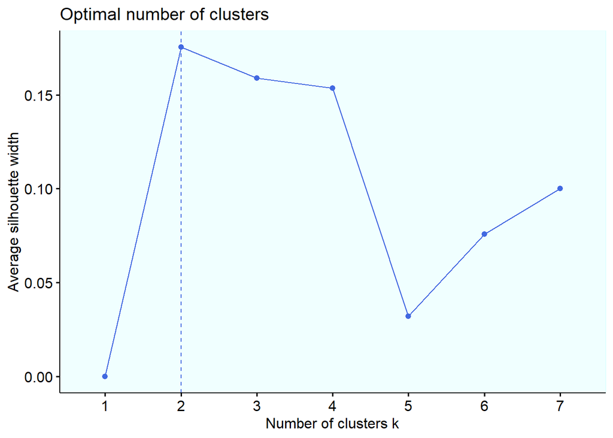

```r
library(klaR)

factoextra::fviz_nbclust(x=myMMcondition, FUN = klaR::kmodes, method = "silhouette", diss = distancias, k.max = 7, linecolor = '#4169E1')+



  theme(panel.background = element_rect(fill = "#F0FFFF", colour = "#E0FFFF",
             size = 0.5, linetype = "solid"),
  panel.grid = element_line(size = 0.25, linetype = 'solid',
                                colour = "#B4CDCD"),
  axis.text = element_text(colour = "black"),
  axis.title = element_text(colour = "black"))
```

If it doesn’t run, remove the `diss` part. Otherwise, it calculates the Euclidean distance, which isn’t what we want.

```r
set.seed(43)

factoextra::fviz_nbclust(x=myMMcondition, FUN = klaR::kmodes, method = "gap_stat", diss = distancias, k.max = 7, linecolor = '#4169E1')+



  theme(panel.background = element_rect(fill = "#F0FFFF", colour = "#E0FFFF",
             size = 0.5, linetype = "solid"),
  panel.grid = element_line(size = 0.25, linetype = 'solid',
                                colour = "#B4CDCD"),
  axis.text = element_text(colour = "black"),
  axis.title = element_text(colour = "black"))
```

```
## Error in `colMeans()`:
## ! 'x' debe ser numérico
```

# Others

PONGO K=3, visto lo visto

```r
k=3
```

```r
library(dplyr)
```

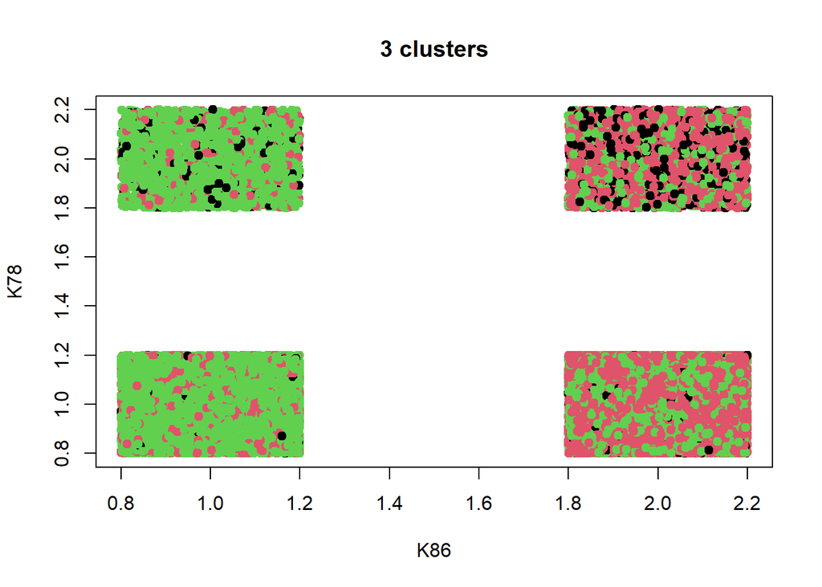

```r
aver=myMMcondition %>%select(c('K86', 'K78'))

aver[sapply(aver, is.factor)] <- lapply(aver[sapply(aver, is.factor)],
                                       as.numeric)


plot(jitter(as.matrix(aver)), col = myresult[[k]]$cluster, pch=19, main=paste(k, 'clusters'))
```

```r
rm(avg_sil, avg_sil_values, i, J, k.values, mediaWithinDiff, num_clusters, SSW)
```

https://stackoverflow.com/questions/41617209/r-clusplot-point-shape

https://stat.ethz.ch/R-manual/R-devel/library/cluster/html/clusplot.default.html

[figure not shown]

```r
library("cluster")

par(bg = '#E0FFFF') # background

clusplot(myMMcondition, myresult[[k]][["cluster"]], color=TRUE, shade=TRUE, labels=2, lines=0) # mal, en teoria, hace otra cosa
```